# Homework 1 (Linear Regression)

# COSC 3337 - Dr. Rizk

### **About The Data**

The data we'll be using comes from the [UCI Machine Learning Repository](https://archive.ics.uci.edu/ml/datasets/wine+quality), and contains the following attributes about red wine:

- fixed acidity
- volatile acidity
- citric acid
- residual sugar
- chlorides
- free sulfur dixoide
- total sulfur dioxide
- density
- pH
- sulphates
- alcohol (%)
- quality

We adjusted the dependent variable, 'quality', to make it a little more continuous.

### **Problem Statement**

Let's say we are part of a data science team that is contracted out as consultants for different companies. In this scenario, we have been assigned a contract with a red wine company which makes a special Cougar Red Blend wine. They have a number of different varieties, each given different quality scores. The wine company has collected different characteristics about their different wines over the years, but they want to know how these variables impact a wine's quality rating. They have no idea what tools to use to do this!

In general, the company would like to know:

- Which variables are significant in predicting the quality of a Cougar Red Blend
- How well those variables describe the quality of the wine

** For the homework assignments, we want you to not only use the tools given in class, but also to be able to *interpret* the results. There are subjective questions, and the grading will be weighted not necessarily on your conclusion, but how you support your conclusion. To do this, you will need to conceptually understand the methods given in class in order to explain results.

** Also, when trying to mimic our results, yours does not need to look exactly like the one given, as long as it is readable **and** answers the question convincingly. Adding comments to code with "#" helps us to understand what you did or were trying to do.

** Please turn in a Jupyter notebook containing your code, its output, and your answers with the file name:

LASTNAME_FIRSTNAME_3337_HW1.ipynb

### **Part 1. Importing Libraries**

Begin by importing the necessary libraries that you'll be using.

Remember, libraries/packages are groups of functions and classes that don't come standard with Python. We are importing these packages so that we can use already-made functions, instead of having to create our own.

As a tip, remember that if you're struggling to understand a function or how to use it, each of these packages has documentation on its website that explains exactly how to use it with examples. Google is your friend :)

```python
# Data Cleaning and Plotting Libraries
import numpy as np
import pandas as pd

import matplotlib.pyplot as plt
import seaborn as sns
from matplotlib import rcParams

# Data Analysis Libraries
from sklearn.linear_model import LinearRegression
from sklearn.preprocessing import StandardScaler, MinMaxScaler
from sklearn.model_selection import train_test_split

# Sets parameters for the entire notebook for Seaborn/Matplotlib plots
rcParams['figure.figsize'] = 10, 7
rcParams.update({'font.size': 12})
sns.set_style('darkgrid')

# If the above codeblock doesn't run, make sure you have each of
# of the packages installed and you are running Python 3.0 or greater
```

### **Part 2. Reading and Understanding the Data**

Import the data using Pandas into a dataframe named `wine_df`. Then, display the first 5 rows

```python
### PUT YOUR CODE HERE TO TRY AND MIMIC THE BELOW OUTPUT

#Load in the wine quality data set
wine_df = pd.read_csv('wine_quality.csv')
wine_df.head()
```

|  | fixed acidity | volatile acidity | citric acid | residual sugar | chlorides | free sulfur dioxide | total sulfur dioxide | density | pH | sulphates | alcohol | quality |
| --- | --- | --- | --- | --- | --- | --- | --- | --- | --- | --- | --- | --- |
| 0 | 7.4 | 0.70 | 0.00 | 1.9 | 0.076 | 11.0 | 34.0 | 0.9978 | 3.51 | 0.56 | 9.4 | 5.182611 |
| 1 | 7.8 | 0.88 | 0.00 | 2.6 | 0.098 | 25.0 | 67.0 | 0.9968 | 3.20 | 0.68 | 9.8 | 4.874886 |
| 2 | 7.8 | 0.76 | 0.04 | 2.3 | 0.092 | 15.0 | 54.0 | 0.9970 | 3.26 | 0.65 | 9.8 | 4.755772 |
| 3 | 11.2 | 0.28 | 0.56 | 1.9 | 0.075 | 17.0 | 60.0 | 0.9980 | 3.16 | 0.58 | 9.8 | 5.783057 |
| 4 | 7.4 | 0.70 | 0.00 | 1.9 | 0.076 | 11.0 | 34.0 | 0.9978 | 3.51 | 0.56 | 9.4 | 5.199293 |

Print some basic statistics of the data

```python
### PUT YOUR CODE HERE TO TRY AND MIMIC THE BELOW OUTPUT

#Check the statistical information about the data set
wine_df.describe()

#There doesn't seem to be missing values that are usually replaced by 0.
# The only column with a min = 0 is citric acid which can totally be 0% in red wine
```

|  | fixed acidity | volatile acidity | citric acid | residual sugar | chlorides | free sulfur dioxide | total sulfur dioxide | density | pH | sulphates | alcohol | quality |
| --- | --- | --- | --- | --- | --- | --- | --- | --- | --- | --- | --- | --- |
| count | 1599.000000 | 1599.000000 | 1599.000000 | 1599.000000 | 1599.000000 | 1599.000000 | 1599.000000 | 1599.000000 | 1599.000000 | 1599.000000 | 1599.000000 | 1599.000000 |
| mean | 8.319637 | 0.527821 | 0.270976 | 2.538806 | 0.087467 | 15.874922 | 46.467792 | 0.996747 | 3.311113 | 0.658149 | 10.422983 | 5.638044 |
| std | 1.741096 | 0.179060 | 0.194801 | 1.409928 | 0.047065 | 10.460157 | 32.895324 | 0.001887 | 0.154386 | 0.169507 | 1.065668 | 0.818458 |
| min | 4.600000 | 0.120000 | 0.000000 | 0.900000 | 0.012000 | 1.000000 | 6.000000 | 0.990070 | 2.740000 | 0.330000 | 8.400000 | 2.948026 |
| 25% | 7.100000 | 0.390000 | 0.090000 | 1.900000 | 0.070000 | 7.000000 | 22.000000 | 0.995600 | 3.210000 | 0.550000 | 9.500000 | 5.017043 |
| 50% | 7.900000 | 0.520000 | 0.260000 | 2.200000 | 0.079000 | 14.000000 | 38.000000 | 0.996750 | 3.310000 | 0.620000 | 10.200000 | 5.786944 |
| 75% | 9.200000 | 0.640000 | 0.420000 | 2.600000 | 0.090000 | 21.000000 | 62.000000 | 0.997835 | 3.400000 | 0.730000 | 11.100000 | 6.096932 |
| max | 15.900000 | 1.580000 | 1.000000 | 15.500000 | 0.611000 | 72.000000 | 289.000000 | 1.003690 | 4.010000 | 2.000000 | 14.900000 | 8.240683 |

```python
#Also check information about the data set
wine_df.info()

#The data set contains 1599 rows over 12 columns.
# There is no obvious null data and all data are numerical type based on the .info table
```

```
<class 'pandas.core.frame.DataFrame'>
RangeIndex: 1599 entries, 0 to 1598
Data columns (total 12 columns):
 #   Column                Non-Null Count  Dtype
---  ------                --------------  -----
 0   fixed acidity         1599 non-null   float64
 1   volatile acidity      1599 non-null   float64
 2   citric acid           1599 non-null   float64
 3   residual sugar        1599 non-null   float64
 4   chlorides             1599 non-null   float64
 5   free sulfur dioxide   1599 non-null   float64
 6   total sulfur dioxide  1599 non-null   float64
 7   density               1599 non-null   float64
 8   pH                    1599 non-null   float64
 9   sulphates             1599 non-null   float64
 10  alcohol               1599 non-null   float64
 11  quality               1599 non-null   float64
dtypes: float64(12)
memory usage: 150.0 KB
```

Create the correlation matrix using Pandas, then using Seaborn, plot a heatmap of the correlation matrix that looks similar to the one below.

HINT: Look at [Matplotlib color map options](https://matplotlib.org/stable/tutorials/colors/colormaps.html) to see if you can find a good color scheme for your heatmap to make it more understandable, and play around with different values of the seaborn heatmap function

```python
########################################### DATA EXPLORATION ###################################################################
```

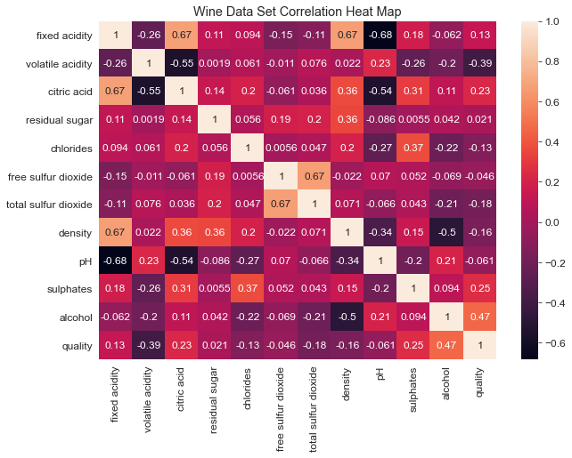

```python
### PUT YOUR CODE HERE TO TRY AND MIMIC THE BELOW OUTPUT

sns.heatmap(wine_df.corr(), annot = True)
plt.title('Wine Data Set Correlation Heat Map')
plt.show()
```

**Q1**: Does this reveal anything interesting for us? If so, what?

(After each question is a cell that we changed from 'Code' to 'Markdown'. Instead of reading Python code, Jupyter will read these as Markdown blocks, which is a way to code/format text. Here is a [Markdown Basic Guide](https://www.markdownguide.org/basic-syntax/))

### Q1:

- Based on the heat map there are some columns that have moderately strong relationship with each other at 0.67 corr score which is still 0.13 below the strong relationship mark at > 0.8.
- These columns are fixed acidity and density as well as citric acid and fixed acidity.
- Overall, the data set does not have any strong relationship between the columns that we would need to address.

Using Seaborn regplots, plot **each** feature in the same style as the plot below. (Use a for loop. There should be 11 plots like the one below. Try experimenting with different colors, too!)

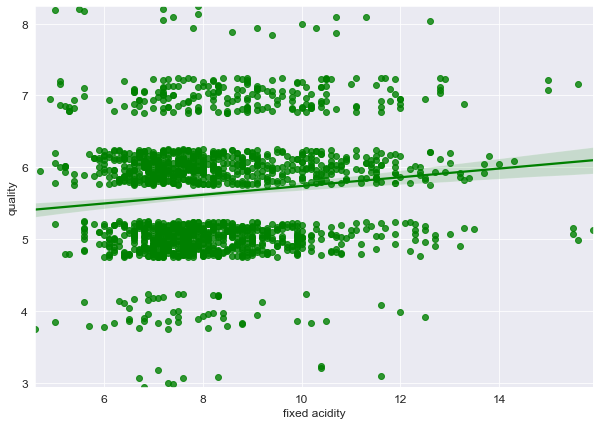

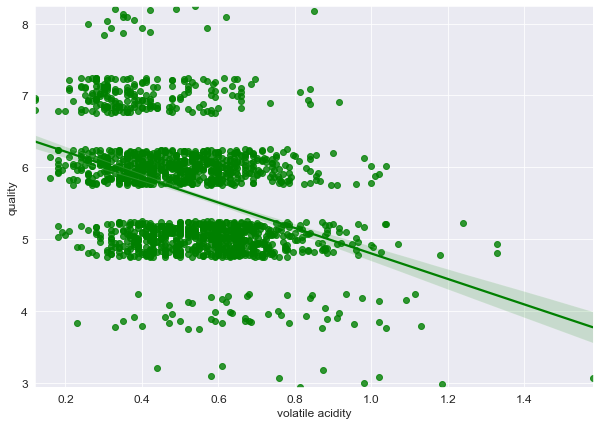

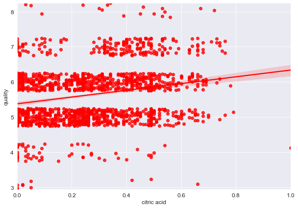

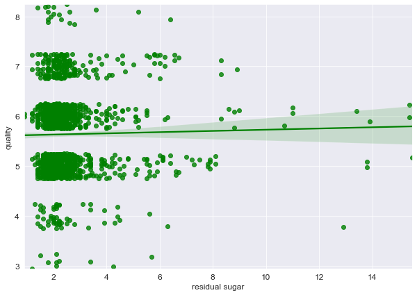

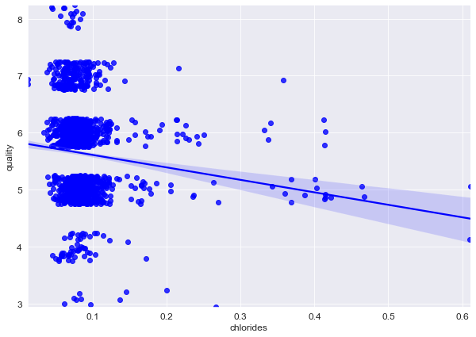

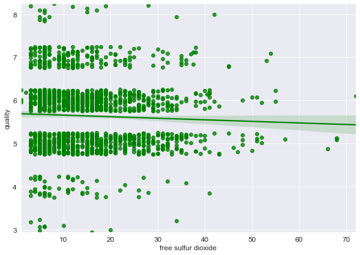

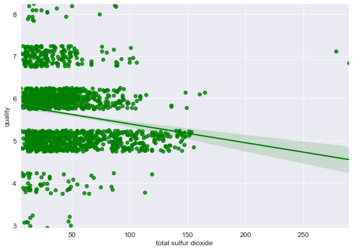

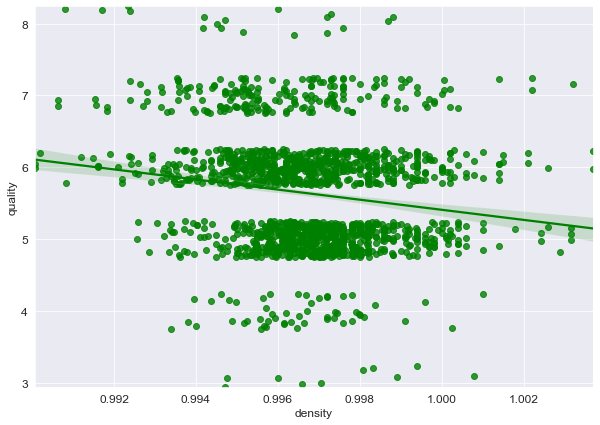

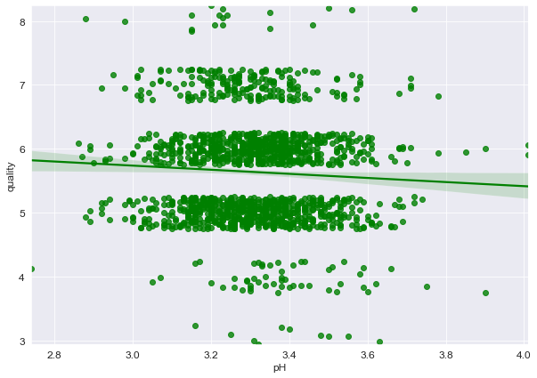

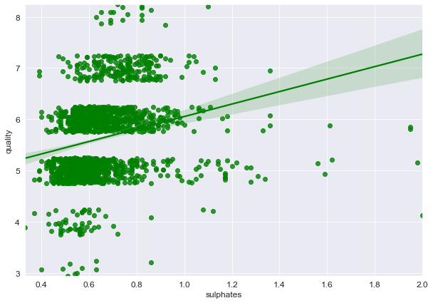

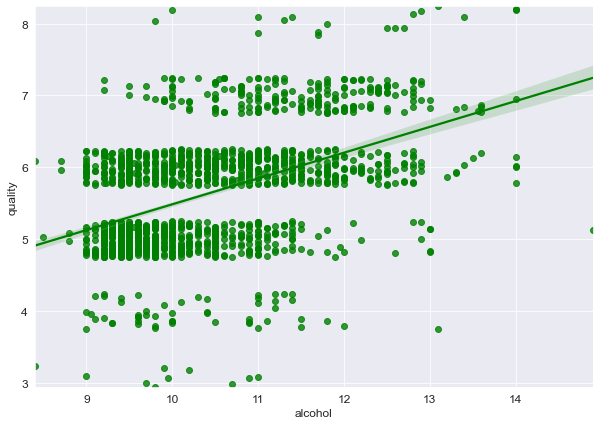

```python
### PUT YOUR CODE HERE TO TRY AND MIMIC THE BELOW OUTPUT

import random
for column in wine_df:
    if column == 'quality':
        next
    else:
        sns.regplot(x = wine_df[column], y = wine_df['quality'], color = random.choice(['red', 'green', 'blue']))
        plt.xlim(wine_df[column].min(), wine_df[column].max())
        plt.ylim(wine_df['quality'].min(), wine_df['quality'].max())

        plt.show()
```

**Q2**: Is there anything that sticks out? What features seem to have the strongest relationship with quality?

**Q3**: How do these findings compare with your conclusions gathered from the correlation matrix?

### Q3:

- Taking a look at the value of volatile acidity with quality in the correlation matrix table, we get -0.39. Meanwhile, the correlation values of sulphates and alcohol level with quality are 0.25 and 0.47, respectively. => The graphs re-confirm the 3 strongest relationships with quality which have been shown previously in the correlation matrix.

```python
############################################# DATA CLEANING AND PREPARATION ##################################################
```

### **Part 3. Data Cleaning and Preparation for Analysis**

Use Pandas to find if there are any missing values in the data set

```python
### PUT YOUR CODE HERE
#To find missing values or null value, we use .info()
wine_df.info()

#There is no missing values that are obvious in this data set.
```

```
<class 'pandas.core.frame.DataFrame'>
RangeIndex: 1599 entries, 0 to 1598
Data columns (total 12 columns):
 #   Column                Non-Null Count  Dtype
---  ------                --------------  -----
 0   fixed acidity         1599 non-null   float64
 1   volatile acidity      1599 non-null   float64
 2   citric acid           1599 non-null   float64
 3   residual sugar        1599 non-null   float64
 4   chlorides             1599 non-null   float64
 5   free sulfur dioxide   1599 non-null   float64
 6   total sulfur dioxide  1599 non-null   float64
 7   density               1599 non-null   float64
 8   pH                    1599 non-null   float64
 9   sulphates             1599 non-null   float64
 10  alcohol               1599 non-null   float64
 11  quality               1599 non-null   float64
dtypes: float64(12)
memory usage: 150.0 KB
```

**Q4:** If there were missing values, how do you think you would deal with them in this data set?

### Q4:

- There is no missing value in this data set but if there were missing values in the wine data set, I would probably use the mean to fill in the missing values. Specifically because every value is numerical and the each value is distributed within a small range.

**Q5:** Are there any categorical features in the data set? If so, which ones are they?

(HINT: Remember, Categorical variables are those whose numbers are representations of a certain category. For example, if there is a "Gender" feature, we might change all "male" values to 1 and all "female" values to 2. In this sense, the numbers don't have any real meaning, but are a way we can turn non-numerical attributes into numbers that we can then use in our models.)

### Q5:

- There are no categorical feature in the wine data set. All data in the data set is continuous numerical.

Using Pandas replace, encode any categorical variables accordingly.

```python
### PUT YOUR CODE HERE
#Independent variables unscaled
X_unscaled = wine_df.drop('quality', axis = 1)
X_unscaled.head()
```

|  | fixed acidity | volatile acidity | citric acid | residual sugar | chlorides | free sulfur dioxide | total sulfur dioxide | density | pH | sulphates | alcohol |
| --- | --- | --- | --- | --- | --- | --- | --- | --- | --- | --- | --- |
| 0 | 7.4 | 0.70 | 0.00 | 1.9 | 0.076 | 11.0 | 34.0 | 0.9978 | 3.51 | 0.56 | 9.4 |
| 1 | 7.8 | 0.88 | 0.00 | 2.6 | 0.098 | 25.0 | 67.0 | 0.9968 | 3.20 | 0.68 | 9.8 |
| 2 | 7.8 | 0.76 | 0.04 | 2.3 | 0.092 | 15.0 | 54.0 | 0.9970 | 3.26 | 0.65 | 9.8 |
| 3 | 11.2 | 0.28 | 0.56 | 1.9 | 0.075 | 17.0 | 60.0 | 0.9980 | 3.16 | 0.58 | 9.8 |
| 4 | 7.4 | 0.70 | 0.00 | 1.9 | 0.076 | 11.0 | 34.0 | 0.9978 | 3.51 | 0.56 | 9.4 |

```python
#Target unscaled
y_unscaled = wine_df['quality']
y_unscaled.head()
```

```
0    5.182611
1    4.874886
2    4.755772
3    5.783057
4    5.199293
Name: quality, dtype: float64
```

In order to run the models, we will create a Pandas dataframe `X`, containing the independent variables, and an array of the dependent variable, `y`. But before we do that, we should scale our data.

However, what's the best way to scale?

First, let's create an `X_unscaled` Pandas dataframe from our `wine_df` dataframe. Then, create a `y_unscaled` Pandas series of the dependent variable, 'quality'.

```python
### PUT YOUR CODE HERE TO TRY AND MIMIC THE BELOW OUTPUT
X_unscaled.columns.tolist
```

```
<bound method IndexOpsMixin.tolist of Index(['fixed acidity', 'volatile acidity', 'citric acid', 'residual sugar',
       'chlorides', 'free sulfur dioxide', 'total sulfur dioxide', 'density',
       'pH', 'sulphates', 'alcohol'],
      dtype='object')>
```

Next, use Sci-Kit Learn's MinMaxScaler and StandardScaler (imported above) to create new sets of pandas dataframes from `X_unscaled`:

- `X_mm` (Using MinMaxScaler)
- `X_ss` (Using StandardScaler)

** The Scaler functions output 2D arrays, so you will need to turn them back into Pandas Dataframes, which can be passed directly to the Linear Regression function.

**Q6**: What statistical assumption does the Standard Scaler make about the data? Why might this be important?

## Q6

- The StandardScaler assumes that our data is normally distributed. If our data is not normally distributed then our scaling result could be skewed to one side.

**Q7**: What do you think the effect will be on using Linear Regression on differently scaled (or unscaled) data?

## Q7

- Since linear regression is heavily dependent on scale, doing the linear regression model on unscaled data will yield the same coefficient result but in properly in different proportions.

```python
### PUT YOUR CODE HERE TO TRY AND MIMIC THE BELOW OUTPUT

#Using StandardScaler to scale independent variables
ss_scaler = StandardScaler()
X_ss = ss_scaler.fit_transform(X_unscaled)
X_ss = pd.DataFrame(data = X_ss, columns = X_unscaled.columns)
X_ss.head()
```

|  | fixed acidity | volatile acidity | citric acid | residual sugar | chlorides | free sulfur dioxide | total sulfur dioxide | density | pH | sulphates | alcohol |
| --- | --- | --- | --- | --- | --- | --- | --- | --- | --- | --- | --- |
| 0 | -0.528360 | 0.961877 | -1.391472 | -0.453218 | -0.243707 | -0.466193 | -0.379133 | 0.558274 | 1.288643 | -0.579207 | -0.960246 |
| 1 | -0.298547 | 1.967442 | -1.391472 | 0.043416 | 0.223875 | 0.872638 | 0.624363 | 0.028261 | -0.719933 | 0.128950 | -0.584777 |
| 2 | -0.298547 | 1.297065 | -1.186070 | -0.169427 | 0.096353 | -0.083669 | 0.229047 | 0.134264 | -0.331177 | -0.048089 | -0.584777 |
| 3 | 1.654856 | -1.384443 | 1.484154 | -0.453218 | -0.264960 | 0.107592 | 0.411500 | 0.664277 | -0.979104 | -0.461180 | -0.584777 |
| 4 | -0.528360 | 0.961877 | -1.391472 | -0.453218 | -0.243707 | -0.466193 | -0.379133 | 0.558274 | 1.288643 | -0.579207 | -0.960246 |

```python
### PUT YOUR CODE HERE TO TRY AND MIMIC THE BELOW OUTPUT

#Using MinMaxScaler to scale independent variables
mm_scaler = MinMaxScaler()
X_mm = mm_scaler.fit_transform(X_unscaled)
X_mm = pd.DataFrame(data = X_mm, columns = X_unscaled.columns)
X_mm.head()
```

|  | fixed acidity | volatile acidity | citric acid | residual sugar | chlorides | free sulfur dioxide | total sulfur dioxide | density | pH | sulphates | alcohol |
| --- | --- | --- | --- | --- | --- | --- | --- | --- | --- | --- | --- |
| 0 | 0.247788 | 0.397260 | 0.00 | 0.068493 | 0.106845 | 0.140845 | 0.098940 | 0.567548 | 0.606299 | 0.137725 | 0.153846 |
| 1 | 0.283186 | 0.520548 | 0.00 | 0.116438 | 0.143573 | 0.338028 | 0.215548 | 0.494126 | 0.362205 | 0.209581 | 0.215385 |
| 2 | 0.283186 | 0.438356 | 0.04 | 0.095890 | 0.133556 | 0.197183 | 0.169611 | 0.508811 | 0.409449 | 0.191617 | 0.215385 |
| 3 | 0.584071 | 0.109589 | 0.56 | 0.068493 | 0.105175 | 0.225352 | 0.190813 | 0.582232 | 0.330709 | 0.149701 | 0.215385 |
| 4 | 0.247788 | 0.397260 | 0.00 | 0.068493 | 0.106845 | 0.140845 | 0.098940 | 0.567548 | 0.606299 | 0.137725 | 0.153846 |

Our final task before performing Linear Regression is to separate our data into training and testing sets. We have 3 different X dataframes, each with the same data but scaled differently:

- `X_unscaled`
- `X_ss`
- `X_mm`

Use Sci-Kit Learn's train_test_split function to create a training and testing set for each of the 3 data sets (Use `y_unscaled` for each of the data sets):

- `train_X_unscaled`, `train_y_unscaled`, `test_X_unscaled`, `test_y_unscaled`
- `train_X_ss`, `train_y_ss`, `test_X_ss`, `test_y_ss`
- `train_X_mm`, `train_y_mm`, `test_X_mm`, `test_y_mm`

Use a train/test split of 80/20

```python
### PUT YOUR CODE HERE
#Splitting data into train and test batches
train_X_unscaled, test_X_unscaled, train_y_unscaled, test_y_unscaled = train_test_split(X_unscaled, y_unscaled, test_size = 0.2, random_state = 129)
train_X_ss, test_X_ss, train_y_ss, test_y_ss = train_test_split(X_ss, y_unscaled, test_size = 0.2, random_state = 129)
train_X_mm, test_X_mm, train_y_mm, test_y_mm = train_test_split(X_mm, y_unscaled, test_size = 0.2, random_state = 129)
```

```python
train_X_ss
```

|  | fixed acidity | volatile acidity | citric acid | residual sugar | chlorides | free sulfur dioxide | total sulfur dioxide | density | pH | sulphates | alcohol |
| --- | --- | --- | --- | --- | --- | --- | --- | --- | --- | --- | --- |
| 1469 | -0.585813 | 2.526090 | -1.134720 | -0.311323 | -0.562513 | 0.394484 | 0.077002 | 0.160764 | -0.007213 | -0.638220 | -0.678644 |
| 773 | -0.241094 | -0.714066 | 0.097691 | -0.524166 | 1.477845 | -1.422500 | -0.075043 | 0.293268 | -0.072005 | 1.545264 | -0.866379 |
| 311 | -0.241094 | 0.012176 | -0.159061 | -0.382271 | -0.328722 | -0.083669 | 1.779904 | -0.395750 | -0.266384 | -0.697233 | -0.960246 |
| 14 | 0.333436 | 0.514959 | -0.467164 | 0.894790 | 1.881666 | 3.454669 | 2.996263 | 0.982285 | -0.979104 | 1.309212 | -1.147981 |
| 89 | -0.758172 | 0.514959 | -0.980669 | -0.524166 | -0.243707 | -0.753085 | -0.683222 | 0.558274 | 1.094265 | -0.756246 | -1.335715 |
| ... | ... | ... | ... | ... | ... | ... | ... | ... | ... | ... | ... |
| 248 | -0.356000 | 0.012176 | -1.083370 | -0.595114 | -0.286214 | -0.657454 | -0.227088 | -0.316248 | 0.251958 | -1.051311 | -0.584777 |
| 1214 | 1.080326 | -1.105120 | 0.970649 | -0.453218 | -0.137438 | -0.944346 | -1.139357 | -0.247346 | -1.367861 | -1.051311 | -0.021574 |
| 1064 | -0.068735 | 1.185336 | -0.929318 | -0.382271 | -0.434990 | -1.039977 | -1.108948 | -1.360375 | -0.201591 | -0.520193 | 1.292568 |
| 231 | -0.183641 | -0.825796 | -1.083370 | -0.524166 | -0.201199 | -0.370562 | 0.077002 | -0.263247 | 0.381544 | -0.815259 | -0.490910 |
| 1119 | -1.562514 | 0.738418 | -1.391472 | -0.027532 | -0.456244 | -0.848716 | -0.956903 | -2.218997 | 1.353436 | -0.461180 | 2.325108 |

1279 rows × 11 columns

```python
########################################### BUILDING MODEL ###################################################################
```

### **Part 4: Model Creation and Evaluation**

Now, we have 3 sets of data sets, and we will use each of them to do Linear Regression modelling. For **each** of the 3 data sets, do the following (the output of using unscaled data is below):

1. Create a Sci-kit Learn Linear Regression model, and train (fit) it on the training data.
2. Use this model to predict quality values for the corresponding test_X values, and save these test predictions as `predictions`.
3. Use `predictions` and `test_y` values to calculate `residuals`
4. Create a Seaborn scatter plot of the true quality vs. the predicted quality of the test set.
5. Create a Seaborn histogram of the residuals.
6. Print the $R^{2}$ value using the test values.

```python
#Creating the linear regression model
lm_unscaled = LinearRegression()
lm_ss = LinearRegression()
lm_mm = LinearRegression()
```

```python
### PUT YOUR CODE HERE TO TRY AND MIMIC THE BELOW OUTPUT FOR UNSCALED DATA

#LM model for unscaled data
lm_unscaled.fit(train_X_unscaled, train_y_unscaled)
predictions_unscaled = lm_unscaled.predict(test_X_unscaled)
unscaled_residuals = test_y_unscaled - predictions_unscaled
print(unscaled_residuals)
```

```
514     0.914711
880    -0.454497
274    -0.009834
944     0.638606
41     -1.264642
          ...
1147    0.996143
1169    0.084399
1023   -0.511327
454    -1.116386
881     0.304724
Name: quality, Length: 320, dtype: float64
```

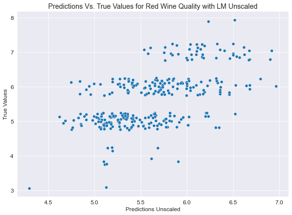

```python
#Scatterplot of predictions vs true values with Lm unscaled
sns.scatterplot(x = predictions_unscaled, y = test_y_unscaled)
plt.xlabel('Predictions Unscaled')
plt.ylabel('True Values')
plt.title('Predictions Vs. True Values for Red Wine Quality with LM Unscaled')
```

```python
#Histogram of residuals from lm unscaled model
sns.histplot(unscaled_residuals, kde = True)
```

[output not shown]

```python
#R2 value for lm unscaled model
from sklearn.metrics import r2_score
print('R2 Score of linear regression with unscaled data:', r2_score(test_y_unscaled, predictions_unscaled))
```

```
R2 Score of linear regression with unscaled data: 0.32866696375549953
```

```python
### PUT YOUR CODE HERE FOR MM SCALED DATA

#LM model for MM data
lm_mm.fit(train_X_mm, train_y_mm)
predictions_mm = lm_mm.predict(test_X_mm)
mm_residuals = test_y_mm - predictions_mm
print(mm_residuals)
```

```
514     0.914711
880    -0.454497
274    -0.009834
944     0.638606
41     -1.264642
          ...
1147    0.996143
1169    0.084399
1023   -0.511327
454    -1.116386
881     0.304724
Name: quality, Length: 320, dtype: float64
```

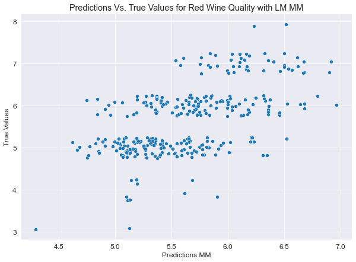

```python
#Scatterplot of predictions vs true values with Lm mm
sns.scatterplot(x = predictions_mm, y = test_y_mm)
plt.xlabel('Predictions MM')
plt.ylabel('True Values')
plt.title('Predictions Vs. True Values for Red Wine Quality with LM MM')
```

```python
#Histogram of residuals from lm unscaled model
sns.histplot(mm_residuals, kde = True)
```

[output not shown]

```python
#R2 value for lm mm model

print('R2 Score of linear regression with mm data:', r2_score(test_y_mm, predictions_mm))
```

```
R2 Score of linear regression with mm data: 0.32866696375550086
```

```python
train_X_ss
```

|  | fixed acidity | volatile acidity | citric acid | residual sugar | chlorides | free sulfur dioxide | total sulfur dioxide | density | pH | sulphates | alcohol |
| --- | --- | --- | --- | --- | --- | --- | --- | --- | --- | --- | --- |
| 1469 | -0.585813 | 2.526090 | -1.134720 | -0.311323 | -0.562513 | 0.394484 | 0.077002 | 0.160764 | -0.007213 | -0.638220 | -0.678644 |
| 773 | -0.241094 | -0.714066 | 0.097691 | -0.524166 | 1.477845 | -1.422500 | -0.075043 | 0.293268 | -0.072005 | 1.545264 | -0.866379 |
| 311 | -0.241094 | 0.012176 | -0.159061 | -0.382271 | -0.328722 | -0.083669 | 1.779904 | -0.395750 | -0.266384 | -0.697233 | -0.960246 |
| 14 | 0.333436 | 0.514959 | -0.467164 | 0.894790 | 1.881666 | 3.454669 | 2.996263 | 0.982285 | -0.979104 | 1.309212 | -1.147981 |
| 89 | -0.758172 | 0.514959 | -0.980669 | -0.524166 | -0.243707 | -0.753085 | -0.683222 | 0.558274 | 1.094265 | -0.756246 | -1.335715 |
| ... | ... | ... | ... | ... | ... | ... | ... | ... | ... | ... | ... |
| 248 | -0.356000 | 0.012176 | -1.083370 | -0.595114 | -0.286214 | -0.657454 | -0.227088 | -0.316248 | 0.251958 | -1.051311 | -0.584777 |
| 1214 | 1.080326 | -1.105120 | 0.970649 | -0.453218 | -0.137438 | -0.944346 | -1.139357 | -0.247346 | -1.367861 | -1.051311 | -0.021574 |
| 1064 | -0.068735 | 1.185336 | -0.929318 | -0.382271 | -0.434990 | -1.039977 | -1.108948 | -1.360375 | -0.201591 | -0.520193 | 1.292568 |
| 231 | -0.183641 | -0.825796 | -1.083370 | -0.524166 | -0.201199 | -0.370562 | 0.077002 | -0.263247 | 0.381544 | -0.815259 | -0.490910 |
| 1119 | -1.562514 | 0.738418 | -1.391472 | -0.027532 | -0.456244 | -0.848716 | -0.956903 | -2.218997 | 1.353436 | -0.461180 | 2.325108 |

1279 rows × 11 columns

```python
### PUT YOUR CODE HERE FOR SS SCALED DATA

#LM model for SS data
lm_ss.fit(train_X_ss, train_y_ss)
predictions_ss = lm_ss.predict(test_X_ss)
ss_residuals = test_y_ss - predictions_ss
print(ss_residuals)
```

```
514     0.914711
880    -0.454497
274    -0.009834
944     0.638606
41     -1.264642
          ...
1147    0.996143
1169    0.084399
1023   -0.511327
454    -1.116386
881     0.304724
Name: quality, Length: 320, dtype: float64
```

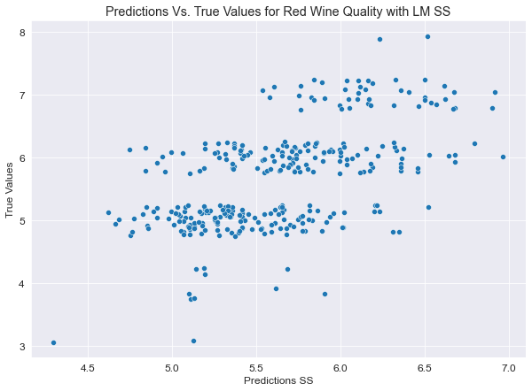

```python
#Scatterplot of predictions vs true values with Lm ss
sns.scatterplot(x = predictions_ss, y = test_y_ss)
plt.xlabel('Predictions SS')
plt.ylabel('True Values')
plt.title('Predictions Vs. True Values for Red Wine Quality with LM SS')
```

```python
#Histogram of residuals from lm unscaled model
sns.histplot(ss_residuals, kde = True)
```

[output not shown]

```python
#R2 value for lm unscaled model

print('R2 Score of linear regression with ss data:', r2_score(test_y_ss, predictions_ss))
```

```
R2 Score of linear regression with ss data: 0.32866696375550064
```

Finally, create a dataframe with all of the coefficients from each of the 3 models and compare.

```python
### PUT YOUR CODE HERE TO TRY AND MIMIC THE BELOW OUTPUT
```

[output not shown]

**Q8**: As is often the case when working on real-world issues, the models may not necessarily fit perfectly. In these models, the $R^2$ values are relatively small. What does the $R^2$ value represent for our models?

## Q8

- The R2 value represents the proportion of the variance for a dependent variable that's explained by an independent variable or variables in a regression model. In our case R2 represents the variance of red wine quality that is explained by fixed acidity, volatile acidity, citric acid, etc.

**Q9**: In your estimation, which model performed the best, and why?

## Q9

- The three models perfomed almost identical in terms of R2 performance. This is also due to the fact that I used the same random_state throughout splitting the three data into unscaled, mm, and ss. I kept the same random_state to truly evaluate the difference in performance between unscaled and scaled data.

**Q10**: We saw that the use of differing standardizing techniques produced different results, with different coefficients and different $R^2$ values. Why do you think this is?

## 10

- In my case, I didn't see any difference in performance with the different standarizing techniques. Thus, that means the difference in performance could be from the different variation of train/test split.

**Report**

The most important part of any data science project is interpretting and communicating the results to the appropriate stakeholder, whether that be a boss, client, or another team member. Given all of the analysis you've done so far, write a short report (2 - 3 paragraphs) summarizing the analysis you did, the results, and the conclusions you came to, supporting your conclusions with your analysis. Feel free to do any more analysis you wish or to modify code you've already used. Curiosity is often rewarded!

### Report

The paper reports the data analysis of the wine data set. The data set consists of twelve columns, in which fixed acidity, volatile acidity, citric acid, residual sugar, chlorides, free sulfur dioxide, total sulfur dioxide, density, pH, sulfates, and alcohol are independent variables, while quality is the dependent variable. There are 1599 evaluations which equate to 1599 rows in the data set. The data contains no null value, with all numbers being continuous numerical.

During data processing for the linear regression model into unscaled, standard scaling, and min-max scaling data, the applied train/test split size is 0.8/0.2. Furthermore, for this particular data analysis, the random_state of all three train/test splits is set to 129 to ensure the data split between all three models is the same in terms of chosen rows. The random_state ensures that the only difference between the three linear regression models is the different scaling methods applied to the data set.

After evaluating the three linear regression models, the R2 result proves that the performance between the three is identical at 0.329 if the train/test split is the same. To further illustrate the point, if random_state is removed, the result between the three models would be different up to 0.1 error in the R2 coefficient. Furthermore, changing random_state to other numbers will yield similar results between the three models. Thus, the three models performed the same. In this case, scaling the data does not affect the model's overall performance. Since the R2 score ranges from 0 to 1, a higher score means the better the model fits the data, a score of 0.329 is not considered a good model to predict wine quality. Specifically, some attributes that have shown no correlation to wine quality should be omitted to create a higher accuracy model.